# Exploratory Analysis

# Exploratory Data Analysis

```python
import pandas as pd
import seaborn as sns
import matplotlib.pyplot as plt
import warnings
from scipy.stats import pearsonr
import random

warnings.filterwarnings('ignore')
sns.set_theme(style="whitegrid")
data = pd.read_csv('../dataset/processed/cleaned_data.csv')
data.head()
```

|  | Movie_Title | Movie_ID | Budget | Cast | Crew | Studios | Genre | Keywords | Languages | Countries | Release_Data | Runtime | Gross_worldwide | Rating | Rating_Count | ListOfCertificate | Release_Year | Release_Month | Release_Day |
| --- | --- | --- | --- | --- | --- | --- | --- | --- | --- | --- | --- | --- | --- | --- | --- | --- | --- | --- | --- |
| 0 | Star Wars: Episode VII - The Force Awakens | 2488496 | 245000000 | ['Daisy Ridley', 'John Boyega', 'Oscar Isaac',... | ['Lawrence Kasdan', 'Michael Arndt', 'J.J. Abr... | ['Lucasfilm', 'Bad Robot', 'Truenorth Producti... | ['Action', 'Adventure', 'Sci-Fi'] | ['reboot', 'sanitation employee', 'remake', 'c... | ['English'] | ['United States'] | 2015-12-18 | 138.0 | 2069521700 | 7.8 | 893000 | ['PG-13'] | 2015 | 12 | 18 |
| 1 | Frozen II | 4520988 | 150000000 | ['Kristen Bell', 'Idina Menzel', 'Josh Gad', '... | ['Jennifer Lee', 'Hans Christian Andersen', 'C... | ['Walt Disney Animation Studios', 'Walt Disney... | ['Animation', 'Adventure', 'Comedy', 'Family',... | ['autumn', 'anthropomorphic snowman', 'princes... | ['English'] | ['United States'] | 2019-11-22 | 103.0 | 1450026933 | 6.8 | 156000 | ['PG'] | 2019 | 11 | 22 |
| 2 | The Dark Knight Rises | 1345836 | 250000000 | ['Christian Bale', 'Tom Hardy', 'Anne Hathaway... | ['Jonathan Nolan', 'Christopher Nolan', 'David... | ['Warner Bros.', 'Legendary Entertainment', 'D... | ['Action', 'Crime', 'Drama'] | ['dc comics', 'batman character', 'bruce wayne... | ['English', 'Arabic'] | ['United Kingdom', 'United States'] | 2012-07-27 | 164.0 | 1081142612 | 8.4 | 1600000 | ['PG-13'] | 2012 | 7 | 27 |
| 3 | Beauty and the Beast | 2771200 | 160000000 | ['Emma Watson', 'Dan Stevens', 'Luke Evans', '... | ['Evan Spiliotopoulos', 'Bill Condon', 'Stephe... | ['Mandeville Films', 'Walt Disney Pictures'] | ['Adventure', 'Family', 'Fantasy', 'Musical', ... | ['beast', 'fairy tale', 'heroine', "beast's he... | ['English'] | ['United States'] | 2017-03-17 | 129.0 | 1273576220 | 7.1 | 293000 | ['PG'] | 2017 | 3 | 17 |
| 4 | Finding Dory | 2277860 | 200000000 | ['Ellen DeGeneres', 'Albert Brooks', "Ed O'Nei... | ['Angus MacLane', 'Victoria Strouse', 'Andrew ... | ['Pixar Animation Studios', 'Walt Disney Pictu... | ['Animation', 'Adventure', 'Comedy', 'Family'] | ['fish', 'ocean', 'whale', 'octopus driving a ... | ['English', 'Indonesian'] | ['United States'] | 2016-06-17 | 97.0 | 1028570942 | 7.3 | 259000 | ['PG'] | 2016 | 6 | 17 |

Load multivalued attributes

```python
import ast

cols = ['Cast', 'Genre', 'Studios', 'ListOfCertificate', 'Keywords', 'Languages', 'Countries', 'Crew']
for col in cols:
    data[col] = data[col].apply(ast.literal_eval)
```

## Multivalued attributes with gross and count

1. Input
- `dataframe`: Dataframe to process
- `col_name`: Name of the column to process, `Cast`, `Genre` and `Studios` for example
1. Output
- Output: Dataframe contains information related to the columns combined with Money and Count

```python
def parseWithMoneyAndCount(dataframe, col_name):
    res = []
    count = []
    gross = []

    for index, record in enumerate(dataframe[col_name]):
        for x in record:
            # Save results to corresponding array
            res.append(x)
            gross.append(dataframe['Gross_worldwide'][index])
            count.append(1)

    # Make dataframe; remove duplicates and sum corresponding columns
    t1 = pd.DataFrame({col_name: res, 'Total': gross, 'Count': count})
    result1 = t1.groupby(col_name).sum()
    result1.reset_index(inplace=True)

    t2 = pd.DataFrame({col_name: res, 'Mean': gross})
    result2 = t2.groupby(col_name).mean()
    result2.reset_index(inplace=True)

    result = result1.merge(result2, on=col_name, how='inner')

    t3 = pd.DataFrame({col_name: res, 'Median': gross})
    result3 = t3.groupby(col_name).median()
    result3.reset_index(inplace=True)

    result = result.merge(result3, on=col_name, how='inner')
    return result
```

## Brief information about data

```python
data.info()
```

```
<class 'pandas.core.frame.DataFrame'>
RangeIndex: 8752 entries, 0 to 8751
Data columns (total 19 columns):
 #   Column             Non-Null Count  Dtype
---  ------             --------------  -----
 0   Movie_Title        8752 non-null   object
 1   Movie_ID           8752 non-null   int64
 2   Budget             8752 non-null   int64
 3   Cast               8752 non-null   object
 4   Crew               8752 non-null   object
 5   Studios            8752 non-null   object
 6   Genre              8752 non-null   object
 7   Keywords           8752 non-null   object
 8   Languages          8752 non-null   object
 9   Countries          8752 non-null   object
 10  Release_Data       8752 non-null   object
 11  Runtime            8752 non-null   float64
 12  Gross_worldwide    8752 non-null   int64
 13  Rating             8752 non-null   float64
 14  Rating_Count       8752 non-null   int64
 15  ListOfCertificate  8752 non-null   object
 16  Release_Year       8752 non-null   int64
 17  Release_Month      8752 non-null   int64
 18  Release_Day        8752 non-null   int64
dtypes: float64(2), int64(7), object(10)
memory usage: 1.3+ MB
```

```python
data.describe()
```

|  | Movie_ID | Budget | Runtime | Gross_worldwide | Rating | Rating_Count | Release_Year | Release_Month | Release_Day |
| --- | --- | --- | --- | --- | --- | --- | --- | --- | --- |
| count | 8.752000e+03 | 8.752000e+03 | 8752.000000 | 8.752000e+03 | 8752.000000 | 8.752000e+03 | 8752.000000 | 8752.000000 | 8752.000000 |
| mean | 1.044857e+06 | 2.351619e+07 | 108.012117 | 7.172680e+07 | 6.430884 | 8.347387e+04 | 2000.010398 | 6.688643 | 16.042162 |
| std | 1.743793e+06 | 3.713275e+07 | 19.559340 | 1.564077e+08 | 1.005946 | 1.641414e+05 | 13.471522 | 3.416011 | 8.602773 |
| min | 1.234900e+04 | 2.200000e+02 | 45.000000 | 9.500000e+01 | 1.400000 | 0.000000e+00 | 1921.000000 | 1.000000 | 1.000000 |
| 25% | 1.023130e+05 | 2.200000e+02 | 95.000000 | 4.443069e+06 | 5.800000 | 7.100000e+03 | 1991.000000 | 4.000000 | 9.000000 |
| 50% | 2.504325e+05 | 1.000000e+07 | 105.000000 | 1.821152e+07 | 6.500000 | 2.600000e+04 | 2002.000000 | 7.000000 | 16.000000 |
| 75% | 1.221610e+06 | 3.000000e+07 | 117.000000 | 6.560984e+07 | 7.200000 | 8.600000e+04 | 2011.000000 | 10.000000 | 23.000000 |
| max | 1.103237e+07 | 3.560000e+08 | 357.000000 | 2.847246e+09 | 9.300000 | 2.500000e+06 | 2021.000000 | 12.000000 | 31.000000 |

## Heatmap of Correlation Matrix, Histogram and Scatter Matrix

```python
cols = ['Budget', 'Runtime', 'Release_Year', 'Gross_worldwide', 'Rating', 'Rating_Count', 'Release_Month']
info = data[cols]
```

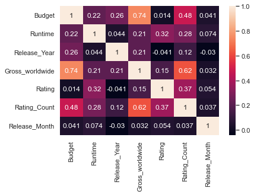

```python
sns.heatmap(info.corr(), annot=True)
```

```
array([[<AxesSubplot:title={'center':'Movie_ID'}>,
        <AxesSubplot:title={'center':'Budget'}>,
        <AxesSubplot:title={'center':'Runtime'}>],
       [<AxesSubplot:title={'center':'Gross_worldwide'}>,
        <AxesSubplot:title={'center':'Rating'}>,
        <AxesSubplot:title={'center':'Rating_Count'}>],
       [<AxesSubplot:title={'center':'Release_Year'}>,
        <AxesSubplot:title={'center':'Release_Month'}>,
        <AxesSubplot:title={'center':'Release_Day'}>]], dtype=object)
```

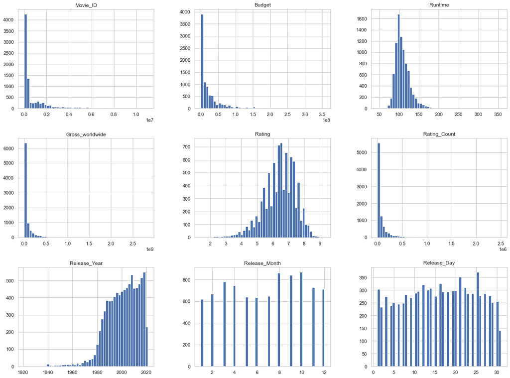

```python
data.hist(bins=50, figsize=(20, 15))
```

```
array([[<AxesSubplot:xlabel='Budget', ylabel='Budget'>,
        <AxesSubplot:xlabel='Runtime', ylabel='Budget'>,
        <AxesSubplot:xlabel='Release_Year', ylabel='Budget'>,
        <AxesSubplot:xlabel='Gross_worldwide', ylabel='Budget'>,
        <AxesSubplot:xlabel='Rating', ylabel='Budget'>,
        <AxesSubplot:xlabel='Rating_Count', ylabel='Budget'>,
        <AxesSubplot:xlabel='Release_Month', ylabel='Budget'>],
       [<AxesSubplot:xlabel='Budget', ylabel='Runtime'>,
        <AxesSubplot:xlabel='Runtime', ylabel='Runtime'>,
        <AxesSubplot:xlabel='Release_Year', ylabel='Runtime'>,
        <AxesSubplot:xlabel='Gross_worldwide', ylabel='Runtime'>,
        <AxesSubplot:xlabel='Rating', ylabel='Runtime'>,
        <AxesSubplot:xlabel='Rating_Count', ylabel='Runtime'>,
        <AxesSubplot:xlabel='Release_Month', ylabel='Runtime'>],
       [<AxesSubplot:xlabel='Budget', ylabel='Release_Year'>,
        <AxesSubplot:xlabel='Runtime', ylabel='Release_Year'>,
        <AxesSubplot:xlabel='Release_Year', ylabel='Release_Year'>,
        <AxesSubplot:xlabel='Gross_worldwide', ylabel='Release_Year'>,
        <AxesSubplot:xlabel='Rating', ylabel='Release_Year'>,
        <AxesSubplot:xlabel='Rating_Count', ylabel='Release_Year'>,
        <AxesSubplot:xlabel='Release_Month', ylabel='Release_Year'>],
       [<AxesSubplot:xlabel='Budget', ylabel='Gross_worldwide'>,
        <AxesSubplot:xlabel='Runtime', ylabel='Gross_worldwide'>,
        <AxesSubplot:xlabel='Release_Year', ylabel='Gross_worldwide'>,
        <AxesSubplot:xlabel='Gross_worldwide', ylabel='Gross_worldwide'>,
        <AxesSubplot:xlabel='Rating', ylabel='Gross_worldwide'>,
        <AxesSubplot:xlabel='Rating_Count', ylabel='Gross_worldwide'>,
        <AxesSubplot:xlabel='Release_Month', ylabel='Gross_worldwide'>],
       [<AxesSubplot:xlabel='Budget', ylabel='Rating'>,
        <AxesSubplot:xlabel='Runtime', ylabel='Rating'>,
        <AxesSubplot:xlabel='Release_Year', ylabel='Rating'>,
        <AxesSubplot:xlabel='Gross_worldwide', ylabel='Rating'>,
        <AxesSubplot:xlabel='Rating', ylabel='Rating'>,
        <AxesSubplot:xlabel='Rating_Count', ylabel='Rating'>,
        <AxesSubplot:xlabel='Release_Month', ylabel='Rating'>],
       [<AxesSubplot:xlabel='Budget', ylabel='Rating_Count'>,
        <AxesSubplot:xlabel='Runtime', ylabel='Rating_Count'>,
        <AxesSubplot:xlabel='Release_Year', ylabel='Rating_Count'>,
        <AxesSubplot:xlabel='Gross_worldwide', ylabel='Rating_Count'>,
        <AxesSubplot:xlabel='Rating', ylabel='Rating_Count'>,
        <AxesSubplot:xlabel='Rating_Count', ylabel='Rating_Count'>,
        <AxesSubplot:xlabel='Release_Month', ylabel='Rating_Count'>],
       [<AxesSubplot:xlabel='Budget', ylabel='Release_Month'>,
        <AxesSubplot:xlabel='Runtime', ylabel='Release_Month'>,
        <AxesSubplot:xlabel='Release_Year', ylabel='Release_Month'>,
        <AxesSubplot:xlabel='Gross_worldwide', ylabel='Release_Month'>,
        <AxesSubplot:xlabel='Rating', ylabel='Release_Month'>,
        <AxesSubplot:xlabel='Rating_Count', ylabel='Release_Month'>,
        <AxesSubplot:xlabel='Release_Month', ylabel='Release_Month'>]],
      dtype=object)
```

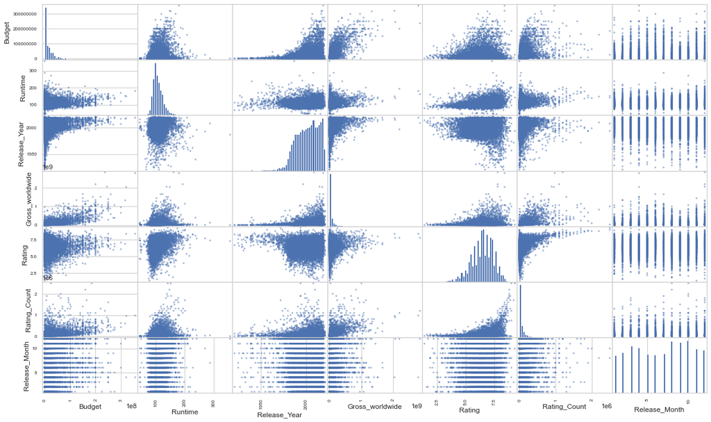

```python
from pandas.plotting import scatter_matrix

scatter_matrix(info, figsize=(20, 12), hist_kwds={'bins': 50})
```

```python
final = data.copy()
```

## `Genre` analysis

```python
genre = parseWithMoneyAndCount(data, 'Genre')
genre
```

|  | Genre | Total | Count | Mean | Median |
| --- | --- | --- | --- | --- | --- |
| 0 | Action | 270712872044 | 1892 | 1.430829e+08 | 50747624.5 |
| 1 | Adventure | 298281440727 | 1515 | 1.968854e+08 | 68514844.0 |
| 2 | Animation | 84311140430 | 400 | 2.107779e+08 | 104469116.5 |
| 3 | Biography | 26964736252 | 663 | 4.067079e+07 | 13448497.0 |
| 4 | Comedy | 222959609180 | 3232 | 6.898503e+07 | 20980459.5 |
| 5 | Crime | 87149222552 | 1589 | 5.484533e+07 | 19870567.0 |
| 6 | Documentary | 2710526736 | 243 | 1.115443e+07 | 2702578.0 |
| 7 | Drama | 224422468047 | 4454 | 5.038672e+07 | 14657538.0 |
| 8 | Family | 137386773092 | 936 | 1.467807e+08 | 51444620.5 |
| 9 | Fantasy | 153116140508 | 981 | 1.560817e+08 | 50693129.0 |
| 10 | Film-Noir | 4890859 | 11 | 4.446235e+05 | 22356.0 |
| 11 | History | 18744144753 | 391 | 4.793899e+07 | 13130349.0 |
| 12 | Horror | 39714174296 | 707 | 5.617281e+07 | 25051865.0 |
| 13 | Music | 19600102040 | 449 | 4.365279e+07 | 11749595.0 |
| 14 | Musical | 30446413474 | 279 | 1.091269e+08 | 22762571.0 |
| 15 | Mystery | 62314981386 | 880 | 7.081248e+07 | 23673201.0 |
| 16 | News | 57917412 | 3 | 1.930580e+07 | 4606199.0 |
| 17 | Romance | 109277844855 | 2201 | 4.964918e+07 | 15164458.0 |
| 18 | Sci-Fi | 152723454914 | 866 | 1.763550e+08 | 51939597.0 |
| 19 | Sport | 16388866644 | 374 | 4.382050e+07 | 17712898.0 |
| 20 | Thriller | 169670494650 | 2224 | 7.629069e+07 | 26492560.5 |
| 21 | War | 20548159884 | 357 | 5.755787e+07 | 15291277.0 |
| 22 | Western | 7393407155 | 143 | 5.170215e+07 | 15164458.0 |

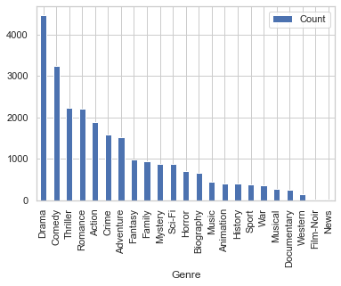

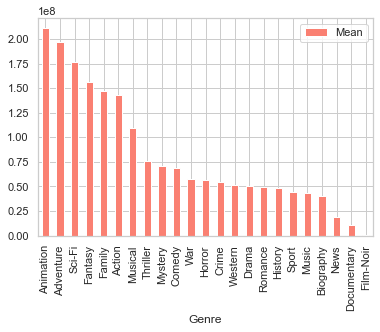

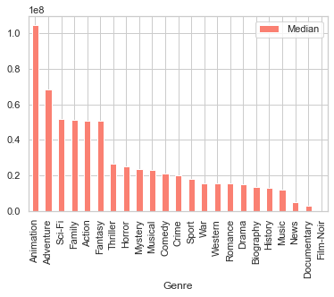

```python
genre.sort_values(by='Count', ascending=False, inplace=True)
genre.plot.bar(x='Genre', y='Count')
genre.sort_values(by='Mean', ascending=False, inplace=True)
genre.plot.bar(x='Genre', y='Mean', color="salmon")
genre.sort_values(by='Median', ascending=False, inplace=True)
genre.plot.bar(x='Genre', y='Median', color="salmon")
```

Film-Noir stays at the lowest position

```python
genre.sort_values(by='Count', ascending=False)
```

|  | Genre | Total | Count | Mean | Median |
| --- | --- | --- | --- | --- | --- |
| 7 | Drama | 224422468047 | 4454 | 5.038672e+07 | 14657538.0 |
| 4 | Comedy | 222959609180 | 3232 | 6.898503e+07 | 20980459.5 |
| 20 | Thriller | 169670494650 | 2224 | 7.629069e+07 | 26492560.5 |
| 17 | Romance | 109277844855 | 2201 | 4.964918e+07 | 15164458.0 |
| 0 | Action | 270712872044 | 1892 | 1.430829e+08 | 50747624.5 |
| 5 | Crime | 87149222552 | 1589 | 5.484533e+07 | 19870567.0 |
| 1 | Adventure | 298281440727 | 1515 | 1.968854e+08 | 68514844.0 |
| 9 | Fantasy | 153116140508 | 981 | 1.560817e+08 | 50693129.0 |
| 8 | Family | 137386773092 | 936 | 1.467807e+08 | 51444620.5 |
| 15 | Mystery | 62314981386 | 880 | 7.081248e+07 | 23673201.0 |
| 18 | Sci-Fi | 152723454914 | 866 | 1.763550e+08 | 51939597.0 |
| 12 | Horror | 39714174296 | 707 | 5.617281e+07 | 25051865.0 |
| 3 | Biography | 26964736252 | 663 | 4.067079e+07 | 13448497.0 |
| 13 | Music | 19600102040 | 449 | 4.365279e+07 | 11749595.0 |
| 2 | Animation | 84311140430 | 400 | 2.107779e+08 | 104469116.5 |
| 11 | History | 18744144753 | 391 | 4.793899e+07 | 13130349.0 |
| 19 | Sport | 16388866644 | 374 | 4.382050e+07 | 17712898.0 |
| 21 | War | 20548159884 | 357 | 5.755787e+07 | 15291277.0 |
| 14 | Musical | 30446413474 | 279 | 1.091269e+08 | 22762571.0 |
| 6 | Documentary | 2710526736 | 243 | 1.115443e+07 | 2702578.0 |
| 22 | Western | 7393407155 | 143 | 5.170215e+07 | 15164458.0 |
| 10 | Film-Noir | 4890859 | 11 | 4.446235e+05 | 22356.0 |
| 16 | News | 57917412 | 3 | 1.930580e+07 | 4606199.0 |

We will develop a **Genre Rank** based on Median but will ignore the film that have number of releases < 10

```python
genre = genre[genre['Count'] > 10]
genre.sort_values(by='Median', ascending=True, inplace=True)
genre.reset_index(drop=True, inplace=True)
genreRank = dict()
for i, row in enumerate(genre['Genre']):
    genreRank[row] = i + 1
genreRank
```

```
{'Film-Noir': 1,
 'Documentary': 2,
 'Music': 3,
 'History': 4,
 'Biography': 5,
 'Drama': 6,
 'Romance': 7,
 'Western': 8,
 'War': 9,
 'Sport': 10,
 'Crime': 11,
 'Comedy': 12,
 'Musical': 13,
 'Mystery': 14,
 'Horror': 15,
 'Thriller': 16,
 'Fantasy': 17,
 'Action': 18,
 'Family': 19,
 'Sci-Fi': 20,
 'Adventure': 21,
 'Animation': 22}
```

We rank the genres by the highest rank of Genre in the list of Genres(Since Genre is multivalued attributes)

```python
def getRank(listGenre):
    max = -1
    for genre in listGenre:
        if genre not in genreRank.keys():
            continue
        if genreRank[genre] > max:
            max = genreRank[genre]
    if max != -1:
        return max
    return 0
```

```
Pearsonr correlation between GenreRank and Gross: 0.253
```

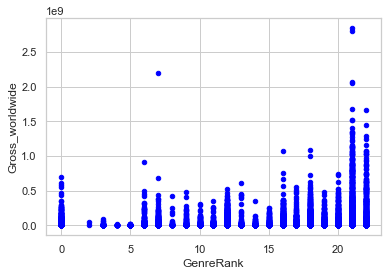

```python
data2 = data.copy()
data2['GenreRank'] = data2['Genre'].apply(getRank)
corr = pearsonr(data2['GenreRank'], data2['Gross_worldwide'])[0]
print('Pearsonr correlation between GenreRank and Gross: %.3f' % corr)
data2.plot.scatter(x='GenreRank', y='Gross_worldwide', color='blue')
```

We rank the genre by total rank of Genre in the list of Genres

```
Pearsons correlation between GenreRank and Gross: 0.316
```

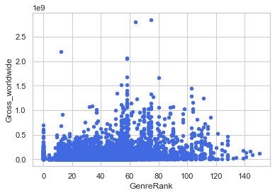

```python
def getRank(listGenre):
    max = -1
    for genre in listGenre:
        if genre not in genreRank.keys():
            continue
        max += genreRank[genre]
    if max != -1:
        return max
    return 0


data2 = data.copy()
data2['GenreRank'] = data2['Genre'].apply(getRank)
corr = pearsonr(data2['GenreRank'], data2['Gross_worldwide'])[0]
print('Pearsons correlation between GenreRank and Gross: %.3f' % corr)
data2.plot.scatter(x='GenreRank', y='Gross_worldwide', color='royalblue')
```

We we rank the genre by average rank of Genre in the list of Genres(Since Genre is multivalued attributes)

```
Pearsons correlation between GenreRank and Gross: 0.325
```

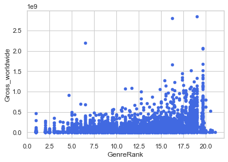

```python
def getRank(listGenre):
    max = 0
    for genre in listGenre:
        if genre not in genreRank.keys():
            continue
        max += genreRank[genre]
    if max == 0:
        return random.randint(1, 15)
    return max / len(listGenre)


data2 = data.copy()
data2['GenreRank'] = data2['Genre'].apply(getRank)
corr = pearsonr(data2['GenreRank'], data2['Gross_worldwide'])[0]
print('Pearsons correlation between GenreRank and Gross: %.3f' % corr)
data2.plot.scatter(x='GenreRank', y='Gross_worldwide', color='royalblue')
```

```python
final['GenreRank'] = data2['GenreRank']
```

Now we will test the hypothesis that movie with Genre **Adventure** will have more value than other movies

```
Pearsons correlation between IsAdventure and Gross: 0.366
```

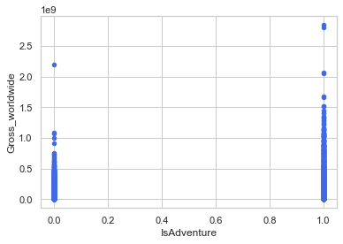

```python
data2 = data.copy()
data2['IsAdventure'] = data2['Genre'].apply(lambda x: 1 if 'Adventure' in x else 0)
corr = pearsonr(data2['IsAdventure'], data2['Gross_worldwide'])[0]
print('Pearsons correlation between IsAdventure and Gross: %.3f' % corr)
data2.plot.scatter(x='IsAdventure', y='Gross_worldwide', color='royalblue')
```

We will choose this one since it has high correlation of 0.366

```python
final['IsAdventure'] = data2['IsAdventure']
```

## Release_Day analysis

```python
data2 = data.copy()
data2['Release_Data'] = pd.to_datetime(data2['Release_Data'], format='%Y-%m-%d')
data2 = data2.assign(WeekDay=data2['Release_Data'].dt.weekday + 2)
data2['WeekDay'].value_counts()
```

```
6    6790
4    1004
5     624
7     131
3      89
2      60
8      54
Name: WeekDay, dtype: int64
```

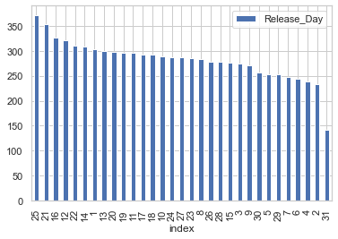

```python
data['Release_Day'].value_counts().reset_index().plot.bar(x='index', y='Release_Day')
```

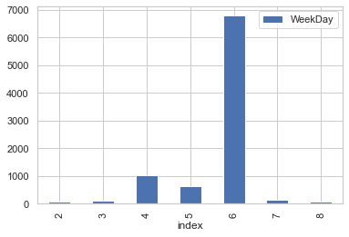

```python
data2['WeekDay'].value_counts().reset_index().sort_values(by='index').plot.bar(x='index', y='WeekDay')
```

Movies tend to release in Friday

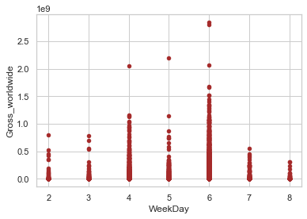

```python
data2.plot.scatter(x='WeekDay', y='Gross_worldwide', color='brown')
```

No linear relation

```
Pearsons correlation between WeekDay and Gross: 0.003
```

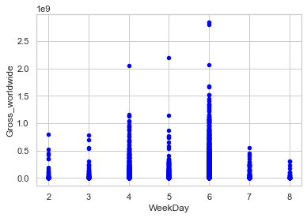

```python
corr = pearsonr(data2['WeekDay'], data2['Gross_worldwide'])[0]
print('Pearsons correlation between WeekDay and Gross: %.3f' % corr)
data2.plot.scatter(x='WeekDay', y='Gross_worldwide', color='blue')
```

Hypothesis: Did movies released in Friday or Wednesday have more gross then others?

```
Pearsons correlation between IsFriWed and Gross: 0.047
```

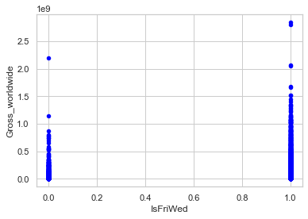

```python
data2['IsFriWed'] = data2['WeekDay'].apply(lambda x: 1 if x in [4, 6] else 0)
corr = pearsonr(data2['IsFriWed'], data2['Gross_worldwide'])[0]
print('Pearsons correlation between IsFriWed and Gross: %.3f' % corr)
data2.plot.scatter(x='IsFriWed', y='Gross_worldwide', color='blue')
```

Not very relevant between them!

## Release_Month analysis

Number of release by month

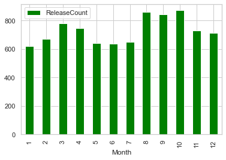

```python
month = data['Release_Month'].value_counts().reset_index().sort_values(by='index', ascending=True)
month = month.rename(columns={'index': 'Month', 'Release_Month': 'ReleaseCount'})
month.plot.bar(x='Month', y='ReleaseCount', color='green')
```

How average gross depend on Release_Month and combine with Release_Year.

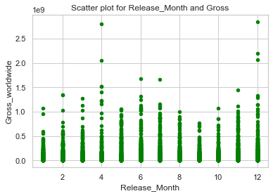

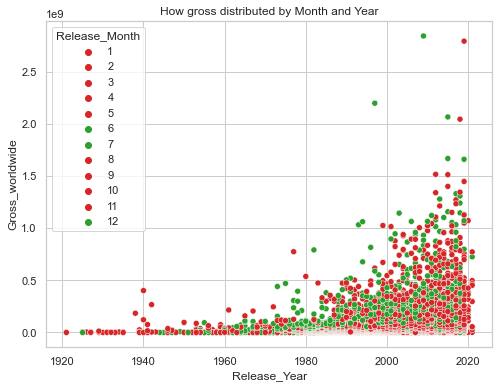

```python
cols = ['Release_Month', 'Gross_worldwide']

data.plot.scatter(x='Release_Month', y='Gross_worldwide', color='green')
plt.title("Scatter plot for Release_Month and Gross")
#3
gColor = [6, 7, 12]
rColor = [1, 2, 3, 4, 5, 8, 9, 10, 11]
colorMap = dict()
for i in gColor:
    colorMap[i] = 'tab:green'
for i in rColor:
    colorMap[i] = 'tab:red'
C = colorMap
fig = plt.figure(figsize=(8, 6))
sns.scatterplot(data=data, x='Release_Year', y='Gross_worldwide', hue='Release_Month', palette=C)
plt.title("How gross distributed by Month and Year")
plt.show()
```

We can see that gross tends to increase by year.

```python
corr = pearsonr(data2['Release_Year'], data2['Gross_worldwide'])[0]
print('Pearsons correlation between Release_Year and Gross: %.3f' % corr)
```

```
Pearsons correlation between Release_Year and Gross: 0.209
```

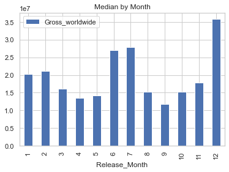

```python
cols = ['Release_Month', 'Gross_worldwide']

month = data[cols]
month = month.groupby("Release_Month").median().reset_index()
#
month.plot.bar(x='Release_Month', y='Gross_worldwide')
plt.title("Median by Month")
```

```
Pearsons correlation between SpecialMonth and Gross: 0.120
```

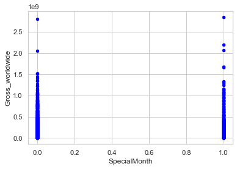

```python
def getSpecialMonth(month):
    specialMonth = [6, 7, 12]
    if month in specialMonth:
        return 1
    else:
        return 0


data2 = data.copy()
data2['SpecialMonth'] = data2['Release_Month'].apply(getSpecialMonth)
corr = pearsonr(data2['SpecialMonth'], data2['Gross_worldwide'])[0]
print('Pearsons correlation between SpecialMonth and Gross: %.3f' % corr)
data2.plot.scatter(x='SpecialMonth', y='Gross_worldwide', color='blue')
```

This correlation is low. We will consider by Mean instead

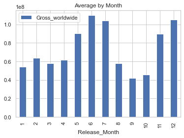

```python
month = data[cols]
month = month.groupby("Release_Month").mean().reset_index()
#1
month.plot.bar(x='Release_Month', y='Gross_worldwide')
plt.title("Average by Month")
```

By Mean Plot of Month and Gross. We can see that 5,6,7,11,12 is the month that are top month(We call special month)

```
Pearsons correlation between SpecialMonth and Gross: 0.142
```

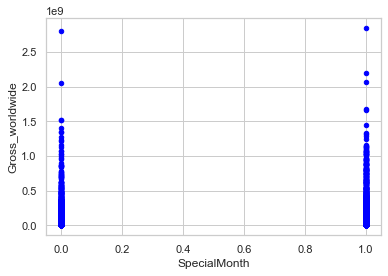

```python
def getSpecialMonth(month):
    specialMonth = [5, 6, 7, 11, 12]
    if month in specialMonth:
        return 1
    else:
        return 0


data2 = data.copy()
data2['SpecialMonth'] = data2['Release_Month'].apply(getSpecialMonth)
corr = pearsonr(data2['SpecialMonth'], data2['Gross_worldwide'])[0]
print('Pearsons correlation between SpecialMonth and Gross: %.3f' % corr)
data2.plot.scatter(x='SpecialMonth', y='Gross_worldwide', color='blue')
```

This has higher correlation so we will choose it

```python
final['SpecialMonth'] = data2['SpecialMonth']
```

## Budget analysis

```python
data['Gross_worldwide'].describe()
```

```
count    8.752000e+03
mean     7.172680e+07
std      1.564077e+08
min      9.500000e+01
25%      4.443069e+06
50%      1.821152e+07
75%      6.560984e+07
max      2.847246e+09
Name: Gross_worldwide, dtype: float64
```

```python
data['Budget'].describe()
```

```
count    8.752000e+03
mean     2.351619e+07
std      3.713275e+07
min      2.200000e+02
25%      2.200000e+02
50%      1.000000e+07
75%      3.000000e+07
max      3.560000e+08
Name: Budget, dtype: float64
```

Relation between Budget and Gross_worldwide

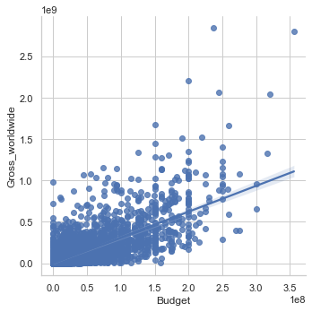

```python
sns.lmplot(data=data, x='Budget', y='Gross_worldwide')
```

Now we will test the correlation between Budget and Gross_WorldWide

```python
corr = pearsonr(data['Budget'], data['Gross_worldwide'])[0]
print('Pearsons correlation between Budget and Gross: %.3f' % corr)
```

```
Pearsons correlation between Budget and Gross: 0.741
```

Budget and Gross_worldwide correlation may perform very well in our future model

## Cast Analysis

Hypothesis: Is Gross depend on number of actors showed on movie's imdb webpage?

```python
data2 = data.copy()
data2['numCast'] = data2['Cast'].apply(lambda x: len(x))
corr = pearsonr(data2['numCast'], data2['Gross_worldwide'])[0]
data2['numCast'].value_counts()
```

```
18    8203
16      66
17      64
15      62
14      53
13      48
12      45
10      35
11      35
9       26
8       23
7       17
6       17
5       12
1       11
4       11
3       11
2        8
0        5
Name: numCast, dtype: int64
```

```
Pearsons correlation between numCast and Gross: 0.059
```

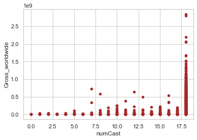

```python
corr = pearsonr(data2['numCast'], data2['Gross_worldwide'])[0]
print('Pearsons correlation between numCast and Gross: %.3f' % corr)
data2.plot.scatter(x='numCast', y='Gross_worldwide', color='brown')
```

->>Very low correlation

Since all imdb pages tend to have more than 17 casts per page

Cast and average gross of the movies they cast for

```python
cast = parseWithMoneyAndCount(data, 'Cast')
cast.sort_values(by='Count', ascending=False, inplace=True)
cast
```

|  | Cast | Total | Count | Mean | Median |
| --- | --- | --- | --- | --- | --- |
| 61269 | Samuel L. Jackson | 18580682439 | 83 | 2.238636e+08 | 62022014.0 |
| 58569 | Robert De Niro | 6722811414 | 77 | 8.730924e+07 | 45491656.0 |
| 49987 | Morgan Freeman | 10397736669 | 65 | 1.599652e+08 | 95943453.0 |
| 33993 | John Goodman | 6019264965 | 62 | 9.708492e+07 | 37207906.0 |
| 41569 | Liam Neeson | 7206028513 | 61 | 1.181316e+08 | 48878502.0 |
| ... | ... | ... | ... | ... | ... |
| 28218 | István Znamenák | 1240663 | 1 | 1.240663e+06 | 1240663.0 |
| 28219 | Italia Coppola | 636796 | 1 | 6.367960e+05 | 636796.0 |
| 28221 | Italo Renda | 34861529 | 1 | 3.486153e+07 | 34861529.0 |
| 28222 | Itandehui Gutierrez | 120673227 | 1 | 1.206732e+08 | 120673227.0 |
| 73025 | Þrúður Kristjánsdóttir | 727594 | 1 | 7.275940e+05 | 727594.0 |

73026 rows × 5 columns

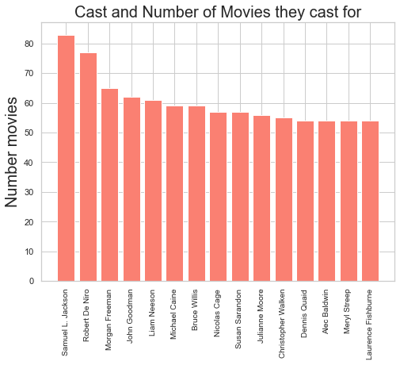

```python
fig = plt.figure(figsize=(8, 6))
# plt.subplot(2,1,1)
data2 = cast.sort_values(by='Count', ascending=False)[0:15]
plt.bar(data=data2, x='Cast', height='Count', color="salmon")
plt.xticks(rotation=90, fontsize=10)
plt.ylabel("Number movies", fontsize=20)
plt.title("Cast and Number of Movies they cast for", fontsize=20)
```

Our data has name of 73026 casts

```python
cast3Movies = cast[cast['Count'] < 3]
cast3Movies.sort_values(by='Median', ascending=False, inplace=True)
cast3Movies
```

|  | Cast | Total | Count | Mean | Median |
| --- | --- | --- | --- | --- | --- |
| 62173 | Sean Anthony Moran | 2847246203 | 1 | 2.847246e+09 | 2.847246e+09 |
| 30536 | Jason Whyte | 2847246203 | 1 | 2.847246e+09 | 2.847246e+09 |
| 62306 | Sean Patrick Murphy | 2847246203 | 1 | 2.847246e+09 | 2.847246e+09 |
| 29659 | James Patrick Pitt | 2847246203 | 1 | 2.847246e+09 | 2.847246e+09 |
| 38160 | Kelly Kilgour | 2847246203 | 1 | 2.847246e+09 | 2.847246e+09 |
| ... | ... | ... | ... | ... | ... |
| 25851 | Hammou Abaou | 95 | 1 | 9.500000e+01 | 9.500000e+01 |
| 31262 | Jeff Prewett | 95 | 1 | 9.500000e+01 | 9.500000e+01 |
| 28953 | Jacqueline Harris | 95 | 1 | 9.500000e+01 | 9.500000e+01 |
| 46652 | Matthew R. Anderson | 95 | 1 | 9.500000e+01 | 9.500000e+01 |
| 34893 | Jonas Ball | 95 | 1 | 9.500000e+01 | 9.500000e+01 |

61310 rows × 5 columns

It will cause problem of not reliable rank when we try to develop a rank system is this type of fields

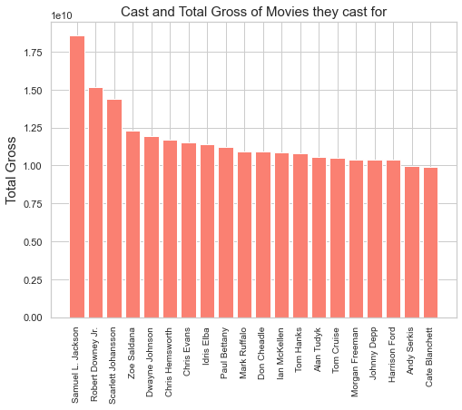

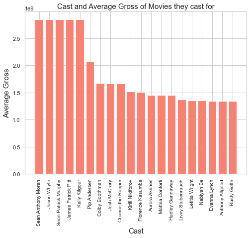

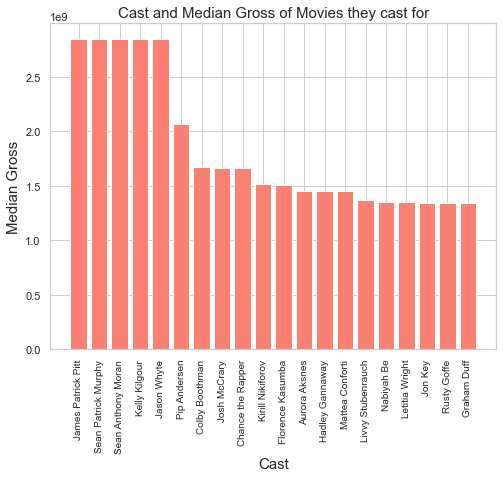

```python
fig = plt.figure(figsize=(8, 6))
# plt.subplot(2,1,1)
data2 = cast.sort_values(by='Total', ascending=False)[0:20]
plt.bar(data=data2, x='Cast', height='Total', color="salmon")
plt.xticks(rotation=90, fontsize=10)
plt.ylabel("Total Gross", fontsize=15)
plt.title("Cast and Total Gross of Movies they cast for", fontsize=15)
fig = plt.figure(figsize=(8, 6))
# plt.subplot(2,1,2)
data3 = cast.sort_values(by='Mean', ascending=False)[0:20]
plt.bar(data=data3, x='Cast', height='Mean', color="salmon")
plt.xticks(rotation=90, fontsize=10)
plt.title("Cast and Average Gross of Movies they cast for", fontsize=15)
plt.xlabel("Cast", fontsize=15)
plt.ylabel("Average Gross", fontsize=15)

fig = plt.figure(figsize=(8, 6))
data3 = cast.sort_values(by='Median', ascending=False)[0:20]
plt.bar(data=data3, x='Cast', height='Median', color="salmon")
plt.xticks(rotation=90, fontsize=10)
plt.title("Cast and Median Gross of Movies they cast for", fontsize=15)
plt.xlabel("Cast", fontsize=15)
plt.ylabel("Median Gross", fontsize=15)
plt.show()
```

Those casts name is not very well-known. **Jason Whyte** and **Sean Anthony Moran** is casts with only 1 movies attended

Now we will develop a rank system for cast (Find top leader casts)